# Exploratory Data Analysis I

# 1 Exploratory Data Analysis (EDA) I

## 1.1 R with R Studio and/or R Studio.cloud

### 1.1.1 Course Contents

1. 2022-12-07: Introduction: About the course [lead by TK] - An introduction to open and public data, and data science
2. 2022-12-14: Exploratory Data Analysis (EDA) 1 [lead by hs]  
   - R Basics with RStudio and/or RStudio.cloud; Toy Data
3. 2022-12-21: Exploratory Data Analysis (EDA) 2 [lead by hs]  
   - R Markdown; Introduction to `tidyverse` I; Public Data, WDI
4. 2023-01-11: Exploratory Data Analysis (EDA) 3 [lead by hs]  
   - Introduction to `tidyverse`II; WDI, WIR, etc
5. 2023-01-18: Exploratory Data Analysis (EDA) 4 [lead by hs]  
   - Introduction to `tidyverse` III; WDI, WIR, etc
6. 2023-01-25: Exploratory Data Analysis (EDA) 5 [lead by hs]  
   - Introduction to `tidyverse` III; WDI, WIR, etc
7. 2023-02-01: Introduction to PPDAC (Problem-Plan-Data-Analysis-Conclusion) Cycle: [lead by TK]
8. 2023-02-08: Model building I [lead by TK] -Collecting and visualizing data and Introduction to WDI  
   (World Development Indicators by World Bank)
9. 2023-02-15: Model building II [lead by TK] -Analyzing data and communications
10. 2023-02-22: Project Presentation

### 1.1.2 Learning Resources

#### 1.1.2.1 Textbooks and References

- “R for Data Science” by Hadley Wickham and Garrett Grolemund:
  - Free Online Book: https://r4ds.had.co.nz
- Visit `bookdown` site: https://bookdown.org
  - Many more on the [archive page](https://bookdown.org/home/archive/).

### 1.1.3 Interactive Exercises

- Posit Primers:https://posit.cloud/learn/primers:
  - The Basics, Work with Data, Visualize Data, Tidy Your Data, Report Reproducibly
- {swirl} Learn R, in R: https://swirlstats.com
  - Designed and developed by a team at Johns Hopkins University for `coursera` courses

### 1.1.4 Posit Primers created by `learnr`

- [`learnr` Interactive Tutorials for R](https://rstudio.github.io/learnr/index.html)

#### 1.1.4.1 Posit Primers https://posit.cloud/learn/primers

1. The Basics – [r4ds: Explore, I](https://r4ds.had.co.nz/explore-intro.html#explore-intro)
- [Visualization Basics](https://rstudio.cloud/learn/primers/1.1)
- [Programming Basics](https://rstudio.cloud/learn/primers/1.2)
2. Work with Data – [r4ds: Wrangle, I](https://r4ds.had.co.nz/wrangle-intro.html#wrangle-intro)
- Working with Tibbles
- Isolating Data with dplyr
- Deriving Information with dplyr
3. Visualize Data – [r4ds: Explore, II](https://r4ds.had.co.nz/explore-intro.html#explore-intro)
4. Tidy Your Data – [r4ds: Wrangle, II](https://r4ds.had.co.nz/wrangle-intro.html#wrangle-intro)
5. Iterate – [r4ds: Program](https://r4ds.had.co.nz/program-intro.html#program-intro)
6. Write Functions – [r4ds: Program](https://r4ds.had.co.nz/program-intro.html#program-intro)

### 1.1.5 Data Science and EDA

#### 1.1.5.1 Wikipedia https://en.wikipedia.org/wiki/Data_science

> An inter-disciplinary field that uses scientific methods, processes, algorithms and systems to extract knowledge and insights from many structural and unstructured data.
- Create Insights
- Impact Decision Making
- Maintain & Improve Overtime

### 1.1.6 What is R?

#### 1.1.6.1 R (programming language), Wikipedia

- **R is a programming language** and **free software** environment for **statistical computing and graphics** supported by the R Foundation for Statistical Computing.
- The R language is widely used among statisticians and data miners for developing statistical software and data analysis.
- A **GNU package**, the official R software environment is written primarily in C, Fortran, and R itself (thus, it is partially self-hosting) and is freely available under the GNU General Public License.

#### 1.1.6.2 History of R and more

“R Programming for Data Science” by Roger Peng

- [Chapter 2. History and Overview of R](https://bookdown.org/rdpeng/rprogdatascience/history-and-overview-of-r.html)
- [Overview and History of R: Youtube video](https://www.youtube.com/watch?v=STihTnVSZnI&feature=youtu.be)

### 1.1.7 Why R? – Responses by Hadley Wickham

#### 1.1.7.1 [r4ds](https://r4ds.had.co.nz/introduction.html#python-julia-and-friends): R is a great place to start your data science journey because

- R is an environment designed from the ground up to support data science.
- R is not just a programming language, but it is also an interactive environment for doing data science.
- To support interaction, R is a much more flexible language than many of its peers.

#### 1.1.7.2 Why R today?

When you talk about choosing programming languages, I always say you shouldn’t pick them based on technical merits, but rather pick them based on the community. And I think the R community is like really, really strong, vibrant, free, welcoming, and embraces a wide range of domains. So, if there are like people like you using R, then your life is going to be much easier. That’s the first reason.

**Interview**: [“Advice to Young (and Old) Programmers, H. Wickham”](https://www.r-bloggers.com/2018/08/advice-to-young-and-old-programmers-a-conversation-with-hadley-wickham/)

### 1.1.8 What is RStudio? https://posit.com

> RStudio is an integrated development environment, or IDE, for R programming.

#### 1.1.8.1 R Studio (Wikipedia)

RStudio is an integrated development environment (IDE) for R, a programming language for statistical computing and graphics. It is available in two formats: RStudio Desktop is a regular desktop application while RStudio Server runs on a remote server and allows accessing RStudio using a web browser.

### 1.1.9 Installation of R and R Studio

#### 1.1.9.1 R Installation

To download R, go to CRAN, the comprehensive R archive network. CRAN is composed of a set of mirror servers distributed around the world and is used to distribute R and R packages. Don’t try and pick a mirror that’s close to you: instead use the cloud mirror, https://cloud.r-project.org, which automatically figures it out for you.

A new major version of R comes out once a year, and there are 2-3 minor releases each year. It’s a good idea to update regularly.

#### 1.1.9.2 R Studio Installation

Download and install it from http://www.rstudio.com/download.

RStudio is updated a couple of times a year. When a new version is available, RStudio will let you know.

### 1.1.10 R Studio

#### 1.1.10.1 The First Step

1. Start R Studio Application
2. Top Menu: File > New Project > New Directory > New Project > *Directory name or Browse the directory and choose the parent directory you want to create the directory*

#### 1.1.10.2 When You Start the Project

1. Go to the directory you created
2. Double click _‘Directory Name’.Rproj

Or,

1. Start R Studio
2. File > Open Project (or choose from Recent Project)

*In this way the working directory of the session is set to the project directory and R can search releted files without difficulty* (`getwd()`, `setwd()`)

### 1.1.11 Posit Cloud

RStudio Cloud is a lightweight, cloud-based solution that allows anyone to do, share, teach and learn data science online.

#### 1.1.11.1 Cloud Free

- Up to 15 projects total
- 1 shared space (5 members and 10 projects max)
- 15 project hours per month
- Up to 1 GB RAM per project
- Up to 1 CPU per project
- Up to 1 hour background execution time

#### 1.1.11.2 How to Start Posit Cloud

1. Go to https://posit.cloud/
2. Sign Up: *top right*
- Email address or Google account
3. New Project: *Project Name*
4. R Console

## 1.2 Let’s Get Started

Start RStudio and create a project, or login to Posit Cloud and create a project.

### 1.2.1 The First Examples

Input the following codes into Console in the left bottom pane.

- The first two:

```r
head(cars)
```

|  | speed | dist |
| --- | --- | --- |
| 1 | 4 | 2 |
| 2 | 4 | 10 |
| 3 | 7 | 4 |
| 4 | 7 | 22 |
| 5 | 8 | 16 |
| 6 | 9 | 10 |

```r
str(cars)
```

```
'data.frame':   50 obs. of  2 variables:
 $ speed: num  4 4 7 7 8 9 10 10 10 11 ...
 $ dist : num  2 10 4 22 16 10 18 26 34 17 ...
```

- Two more:

```r
summary(cars)
```

```
     speed           dist
 Min.   : 4.0   Min.   :  2.00
 1st Qu.:12.0   1st Qu.: 26.00
 Median :15.0   Median : 36.00
 Mean   :15.4   Mean   : 42.98
 3rd Qu.:19.0   3rd Qu.: 56.00
 Max.   :25.0   Max.   :120.00
```

```r
plot(cars)
```

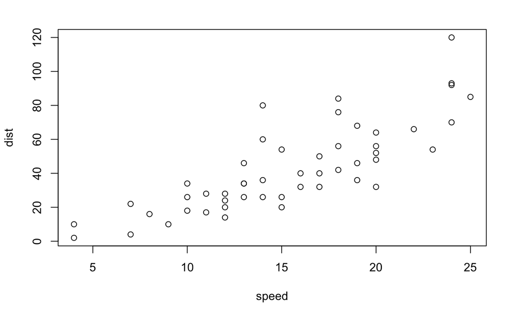

- And three more:

```r
plot(cars) # cars: Speed and Stopping Distances of Cars
abline(lm(cars$dist~cars$speed))
```

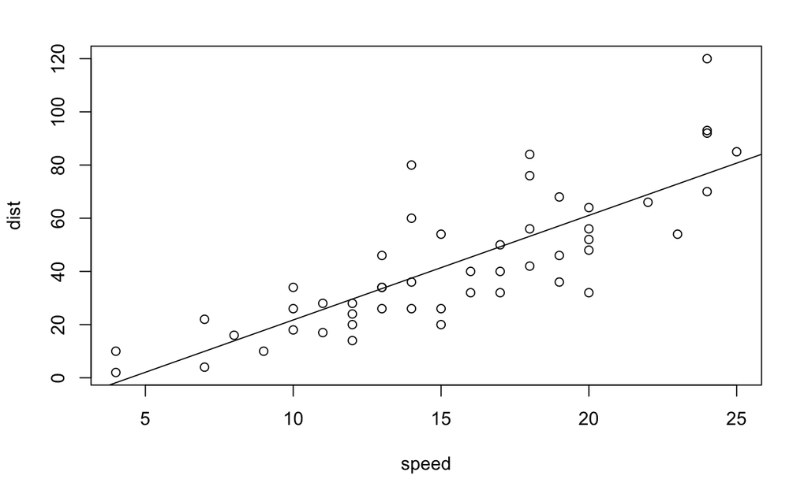

```r
lm(cars$dist~cars$speed)
```

```
Call:
lm(formula = cars$dist ~ cars$speed)

Coefficients:
(Intercept)   cars$speed
    -17.579        3.932
```

```r
summary(lm(cars$dist~cars$speed))
```

```
Call:
lm(formula = cars$dist ~ cars$speed)

Residuals:
    Min      1Q  Median      3Q     Max
-29.069  -9.525  -2.272   9.215  43.201

Coefficients:
            Estimate Std. Error t value Pr(>|t|)
(Intercept) -17.5791     6.7584  -2.601   0.0123 *
cars$speed    3.9324     0.4155   9.464 1.49e-12 ***
---
Signif. codes:  0 ‘***’ 0.001 ‘**’ 0.01 ‘*’ 0.05 ‘.’ 0.1 ‘ ’ 1

Residual standard error: 15.38 on 48 degrees of freedom
Multiple R-squared:  0.6511,    Adjusted R-squared:  0.6438
F-statistic: 89.57 on 1 and 48 DF,  p-value: 1.49e-12
```

#### 1.2.1.1 Brief Explanation

- `head(cars)`: The first 6 rows of the pre-installed data `cars`.
- `str(cars)`: The data structure of the pre-installed data `cars`.
- `summary(cars)`: The summary of the pre-installed data `cars`.
- `plot(cars)`: A scatter plot of the pre-installed data `cars`.
  - `plot(cars$dist~cars$speed)`
  - `cars$dist`, `cars$[[2]]`, `cars[,2]` are same
- `abline(lm(cars$dist~cars$speed))`: Add a regression line of a linear model
- `lm(cars$dist~cars$speed)`: The equation of the regression line
- `summary(lm(cars$dist~cars$speed)`: The summary of the linear regression model

```r
hist(cars$dist)
```

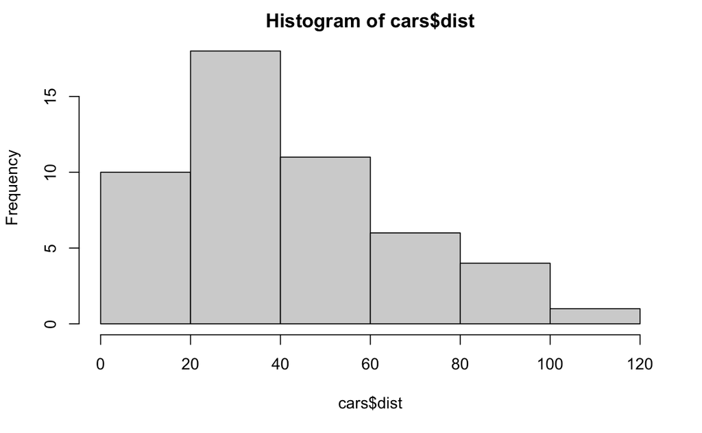

```r
hist(cars$speed)
```

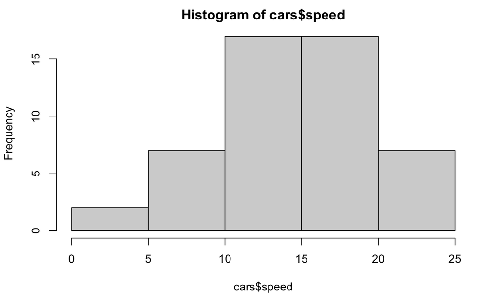

#### 1.2.1.2 View and help

- `View(cars)`
- `?cars`: same as `help(cars)`
- `??cars`: same as `help.search(“cars”)

#### 1.2.1.3 `datasets`

- `?datasets`
- `library(help = "datasets")`
- `data()` shows all data already attached and available.

### 1.2.2 Practicum

Pick a data in the datasets package and try

- `head()`
- `str()`
- `summary()`

and some more.

#### 1.2.2.1 `iris`

```r
head(iris)
```

|  | Sepal.Length | Sepal.Width | Petal.Length | Petal.Width | Species |
| --- | --- | --- | --- | --- | --- |
| 1 | 5.1 | 3.5 | 1.4 | 0.2 | setosa |
| 2 | 4.9 | 3.0 | 1.4 | 0.2 | setosa |
| 3 | 4.7 | 3.2 | 1.3 | 0.2 | setosa |
| 4 | 4.6 | 3.1 | 1.5 | 0.2 | setosa |
| 5 | 5.0 | 3.6 | 1.4 | 0.2 | setosa |
| 6 | 5.4 | 3.9 | 1.7 | 0.4 | setosa |

```r
str(iris)
```

```
'data.frame':   150 obs. of  5 variables:
 $ Sepal.Length: num  5.1 4.9 4.7 4.6 5 5.4 4.6 5 4.4 4.9 ...
 $ Sepal.Width : num  3.5 3 3.2 3.1 3.6 3.9 3.4 3.4 2.9 3.1 ...
 $ Petal.Length: num  1.4 1.4 1.3 1.5 1.4 1.7 1.4 1.5 1.4 1.5 ...
 $ Petal.Width : num  0.2 0.2 0.2 0.2 0.2 0.4 0.3 0.2 0.2 0.1 ...
 $ Species     : Factor w/ 3 levels "setosa","versicolor",..: 1 1 1 1 1 1 1 1 1 1 ...
```

```r
summary(iris)
```

```
  Sepal.Length    Sepal.Width     Petal.Length    Petal.Width          Species
 Min.   :4.300   Min.   :2.000   Min.   :1.000   Min.   :0.100   setosa    :50
 1st Qu.:5.100   1st Qu.:2.800   1st Qu.:1.600   1st Qu.:0.300   versicolor:50
 Median :5.800   Median :3.000   Median :4.350   Median :1.300   virginica :50
 Mean   :5.843   Mean   :3.057   Mean   :3.758   Mean   :1.199
 3rd Qu.:6.400   3rd Qu.:3.300   3rd Qu.:5.100   3rd Qu.:1.800
 Max.   :7.900   Max.   :4.400   Max.   :6.900   Max.   :2.500
```

Can you plot?

```r
plot(iris$Sepal.Length, iris$Sepal.Width)
```

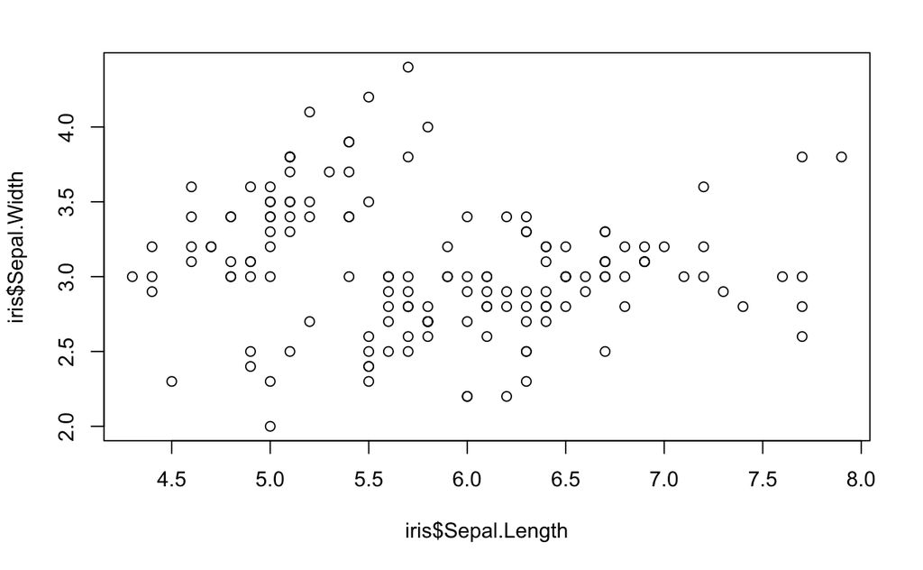

## 1.3 `tidyverse` Packages

### 1.3.1 Brief Introduction to R on RStudio

#### 1.3.1.1 Four Panes and Tabs

1. Top Left: Source Editor
2. Top Right: Environment, History, etc.
3. Bottom Left: Console, Terminal, Render, Background Jobs
4. Bottom Right: Files, Plots, Packages, Help, Viewer, Presentation

#### 1.3.1.2 Set up

- Highly recommend to set the language to be “English”.
- Create “data” directory.

```r
Sys.setenv(LANG = "en")
dir.create("data")
```

#### 1.3.1.3 Three Ways to Run Codes

1. Console - Bottom Left Pane
2. R Script - pull down menu under File
3. R Notebook, R Markdown - pull down menu under File

### 1.3.2 Second Way: R Script

#### 1.3.2.1 Examples: R Scripts in Moodle

- `basics.R`
- `coronavirus.R`
1. Copy a script in Moodle: *{file name}.R*
2. In RStudio (create Project in RStudio) choose File > New File > R Script and paste it.
3. Choose File > Save with a name; e.g. *{file names}* (.R will be added automatically)

To run a code: at the cursor press *Ctrl+Shift+Enter* (Win) or *Cmd+Shift+Enter* (Mac).

### 1.3.3 Packages

R packages are extensions to the R statistical programming language. R packages contain code, data, and documentation in a standardised collection format that can be installed by users of R, typically via a centralised software repository such as CRAN (the Comprehensive R Archive Network).

#### 1.3.3.1 Installation and attachement

You can install packages by “Install Packages…” under “Tool” in the top menu.

- `install.packages("tidyverse")`
- `install.packages("rmarkdown")`

### 1.3.4 Third Way: R Notebook

Choose R Notebook from the pull down File menu in the top bar.

### 1.3.5 Edit YAML

**Default* is as follows**

```
---
title: "R Notebook"
output: html_notebook
---
```

**Template**

```
---
title: "Title of R Notebook"
author: "ID and Your Name"
date: "2022-12-16"
output:
  html_notebook:
#    number_sections: yes
#    toc: true
#    toc_float: true
---
```

- Don’t change the format. Indention matters.
- The statement after # is ignored.
- Date is automatically inserted when you compile the file.
- You can replace “2022-12-16” by “2022-12-14” or in any date format surrounded by double quotation marks.
- Section numbers: - default is `number_sections: no`.
- Table of contents, `toc: true` - default is `toc: false`.
- Floating table of contents in HTML output, `toc_float: true` - default is `toc_float: false`

### 1.3.6 Create a Code Chunk to Attach Packages

Insert Chunk in Code pull down menu in the top bar, or use the `C` button on top. You can use shortcut keys listed under Tools in the top bar.

## 1.4 First Example

### 1.4.1 Importing data

Let us assign the `iris` data in the pre-installed package `datasets` to `df_iris`. You can give any name starting from an alphabet, though there are some rules.

```r
df_iris <- datasets::iris
class(df_iris)
```

```
[1] "data.frame"
```

The class of data `iris` is `data.frame`, the basic data class of R. You can assign the same data as a `tibble`, the data class of `tidyverse` as follows.

```r
tbl_iris <- as_tibble(datasets::iris)
class(tbl_iris)
```

```
[1] "tbl_df"     "tbl"        "data.frame"
```

- `df_iris <- iris` can replace `df_iris <- datasets::iris` because the package `datasets` is installed and attached as default. Since you may have other data called `iris` included in a different package or you may have changed `iris` before, it is safer to specify the name of the package with the name of the data.
- Within R Notebook or in Console, you may get different output, and `tf_iris` and `tbl_iris` behave differently. It is because of the default settings of R Markdown.

### 1.4.2 Look at the data

#### 1.4.2.1 Several ways to view the data.

The `View` command open up a window to show the contents of the data and you can use the filter as well.

```r
View(df_iris)
```

The following simple command also shows the data.

```r
df_iris
```

| Sepal.Length | Sepal.Width | Petal.Length | Petal.Width | Species |
| --- | --- | --- | --- | --- |
| 5.1 | 3.5 | 1.4 | 0.2 | setosa |
| 4.9 | 3.0 | 1.4 | 0.2 | setosa |
| 4.7 | 3.2 | 1.3 | 0.2 | setosa |
| 4.6 | 3.1 | 1.5 | 0.2 | setosa |
| 5.0 | 3.6 | 1.4 | 0.2 | setosa |
| 5.4 | 3.9 | 1.7 | 0.4 | setosa |
| 4.6 | 3.4 | 1.4 | 0.3 | setosa |
| 5.0 | 3.4 | 1.5 | 0.2 | setosa |
| 4.4 | 2.9 | 1.4 | 0.2 | setosa |
| 4.9 | 3.1 | 1.5 | 0.1 | setosa |

[output cut: 140 more lines]

The output within R Notebook is a tibble style. Try the same command in Console.

```r
slice(df_iris, 1:10)
```

| Sepal.Length | Sepal.Width | Petal.Length | Petal.Width | Species |
| --- | --- | --- | --- | --- |
| 5.1 | 3.5 | 1.4 | 0.2 | setosa |
| 4.9 | 3.0 | 1.4 | 0.2 | setosa |
| 4.7 | 3.2 | 1.3 | 0.2 | setosa |
| 4.6 | 3.1 | 1.5 | 0.2 | setosa |
| 5.0 | 3.6 | 1.4 | 0.2 | setosa |
| 5.4 | 3.9 | 1.7 | 0.4 | setosa |
| 4.6 | 3.4 | 1.4 | 0.3 | setosa |
| 5.0 | 3.4 | 1.5 | 0.2 | setosa |
| 4.4 | 2.9 | 1.4 | 0.2 | setosa |
| 4.9 | 3.1 | 1.5 | 0.1 | setosa |

```r
1:10
```

```
 [1]  1  2  3  4  5  6  7  8  9 10
```

#### 1.5.0.1 Data Structure

Let us look at the structure of the data. You can try `str(df_iris)` on Console or by adding a code chunk in R Notebook introducing later.

```r
glimpse(df_iris)
```

```
Rows: 150
Columns: 5
$ Sepal.Length <dbl> 5.1, 4.9, 4.7, 4.6, 5.0, 5.4, 4.6, 5.0, 4.4, 4.9, 5.4, 4.8, 4.8, 4.3, …
$ Sepal.Width  <dbl> 3.5, 3.0, 3.2, 3.1, 3.6, 3.9, 3.4, 3.4, 2.9, 3.1, 3.7, 3.4, 3.0, 3.0, …
$ Petal.Length <dbl> 1.4, 1.4, 1.3, 1.5, 1.4, 1.7, 1.4, 1.5, 1.4, 1.5, 1.5, 1.6, 1.4, 1.1, …
$ Petal.Width  <dbl> 0.2, 0.2, 0.2, 0.2, 0.2, 0.4, 0.3, 0.2, 0.2, 0.1, 0.2, 0.2, 0.1, 0.1, …
$ Species      <fct> setosa, setosa, setosa, setosa, setosa, setosa, setosa, setosa, setosa…
```

There are six types of data in R; Double, Integer, Character, Logical, Raw, Complex.

The names after $ are column names. If you call `df_iris$Species`, you have the Species column. Species is in the 5th collumn, `typeof(df_iris[[5]])` does the same as the next.

```r
typeof(df_iris$Species)
```

```
[1] "integer"
```

```r
class(df_iris$Species)
```

```
[1] "factor"
```

For `factors = fct` see [the R Document](https://www.rdocumentation.org/packages/base/versions/3.6.2/topics/factor) or an explanation in [Factor in R: Categorical Variable & Continuous Variables](https://www.guru99.com/r-factor-categorical-continuous.html).

```r
typeof(df_iris$Sepal.Length)
```

```
[1] "double"
```

```r
class(df_iris$Sepal.Length)
```

```
[1] "numeric"
```

**Q1.** What are the differences of`df_iris`, `slice(df_iris, 1:10)` and `glimpse(df_iris)` above?

**Q2.** What are the differences of`df_iris`, `slice(df_iris, 1:10)` and `glimpse(df_iris)` in the console?

#### 1.5.0.2 Summary of the Data

The following is very convenient to get the summary information of a data.

```r
summary(df_iris)
```

```
  Sepal.Length    Sepal.Width     Petal.Length    Petal.Width          Species
 Min.   :4.300   Min.   :2.000   Min.   :1.000   Min.   :0.100   setosa    :50
 1st Qu.:5.100   1st Qu.:2.800   1st Qu.:1.600   1st Qu.:0.300   versicolor:50
 Median :5.800   Median :3.000   Median :4.350   Median :1.300   virginica :50
 Mean   :5.843   Mean   :3.057   Mean   :3.758   Mean   :1.199
 3rd Qu.:6.400   3rd Qu.:3.300   3rd Qu.:5.100   3rd Qu.:1.800
 Max.   :7.900   Max.   :4.400   Max.   :6.900   Max.   :2.500
```

Minimum, 1st Quadrant (25%), Median, Mean, 3rd Quadrant (75%), Maximum, and the count of each factor.

### 1.5.1 Visualizing Data

#### 1.5.1.1 Scatter Plot

We use `ggplot` to draw graphs. The scatter plot is a projection of data with two variables $x$ and $y$.

```
ggplot(data = <data>, aes(x = <column name for x>, y = <column name for y>)) +
  geom_point()
```

```
ggplot(data = df_iris, aes(x = Sepal.Length, y = Sepal.Width)) +
  geom_point()
```

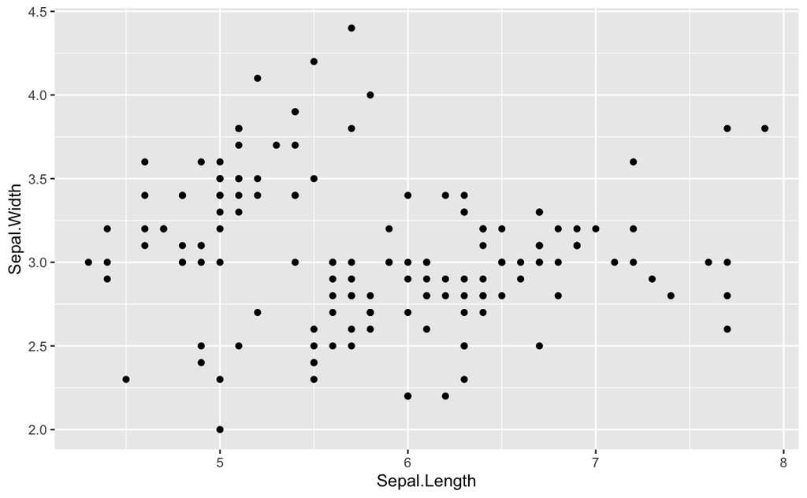

```r
ggplot(data = df_iris, aes(x = Sepal.Length, y = Sepal.Width)) +
  geom_point()
```

#### 1.5.1.2 Scatter Plot with [Labels](https://ggplot2.tidyverse.org/reference/labs.html)

Add title and labels adding `labs()`.

```
ggplot(data = <data>, aes(x = <column name for x>, y = <column name for y>)) +
  geom_point() +
  labs(title = "Title", x = "Label for x", y = "Label for y")
```

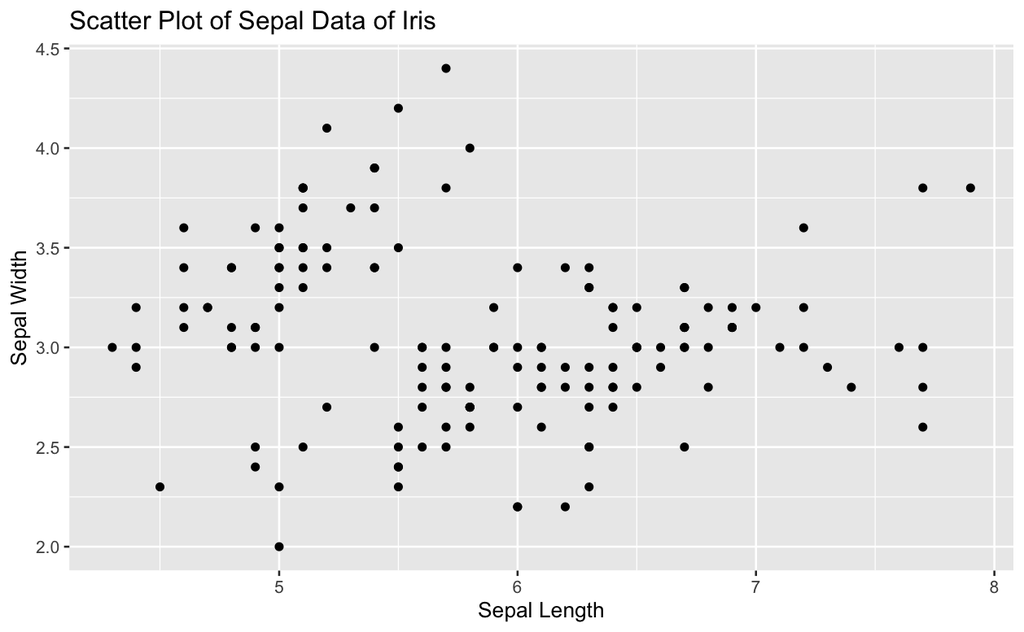

```r
ggplot(data = df_iris, aes(x = Sepal.Length, y = Sepal.Width)) +
  geom_point() +
  labs(title = "Scatter Plot of Sepal Data of Iris", x = "Sepal Length", y = "Sepal Width")
```

#### 1.5.1.3 Scatter Plot with [Colors](https://ggplot2.tidyverse.org/reference/aes_colour_fill_alpha.html)

Add different colors automatically to each species. Can you see each group?

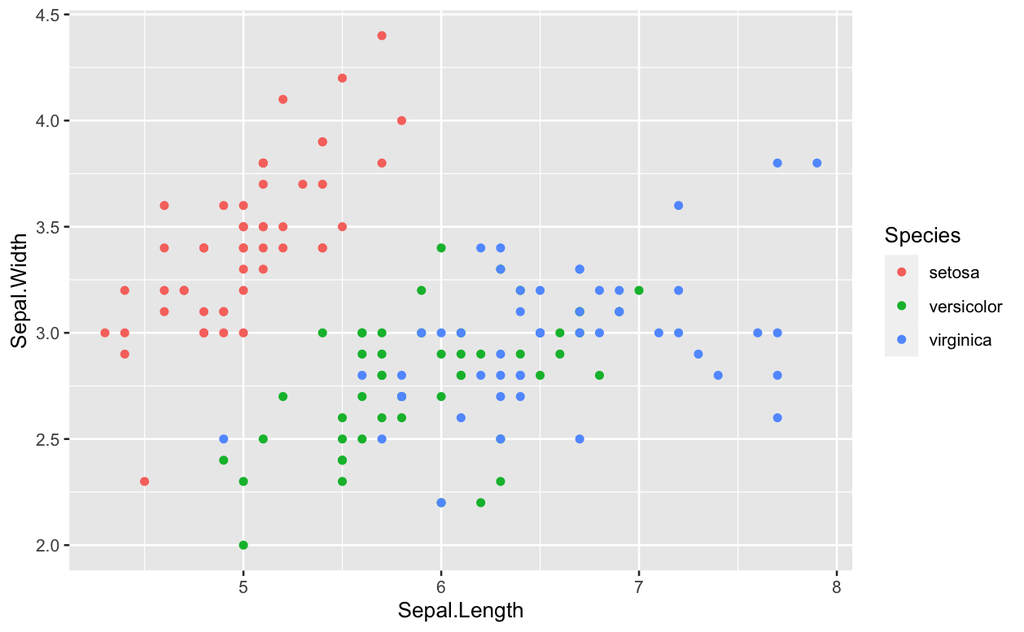

```r
ggplot(data = df_iris, aes(x = Sepal.Length, y = Sepal.Width, color = Species)) +
  geom_point()
```

#### 1.5.1.4 Scatter Plot with Shapes

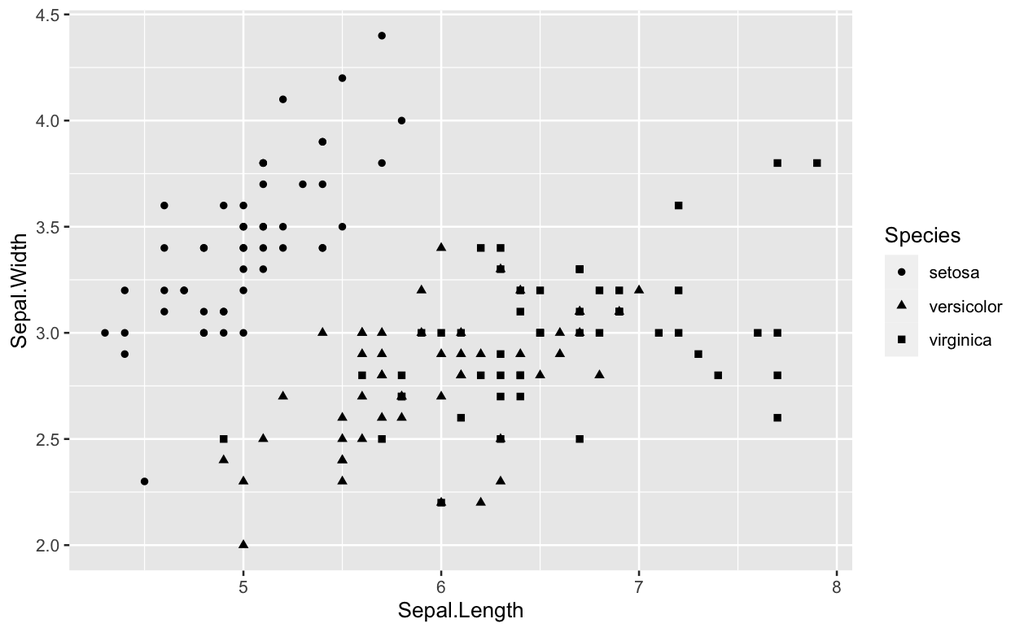

```r
ggplot(data = df_iris, aes(x = Sepal.Length, y = Sepal.Width, shape = Species)) +
  geom_point()
```

#### 1.5.1.5 [Boxplot](https://ggplot2.tidyverse.org/reference/geom_boxplot.html)

The boxplot compactly displays the distribution of a continuous variable.

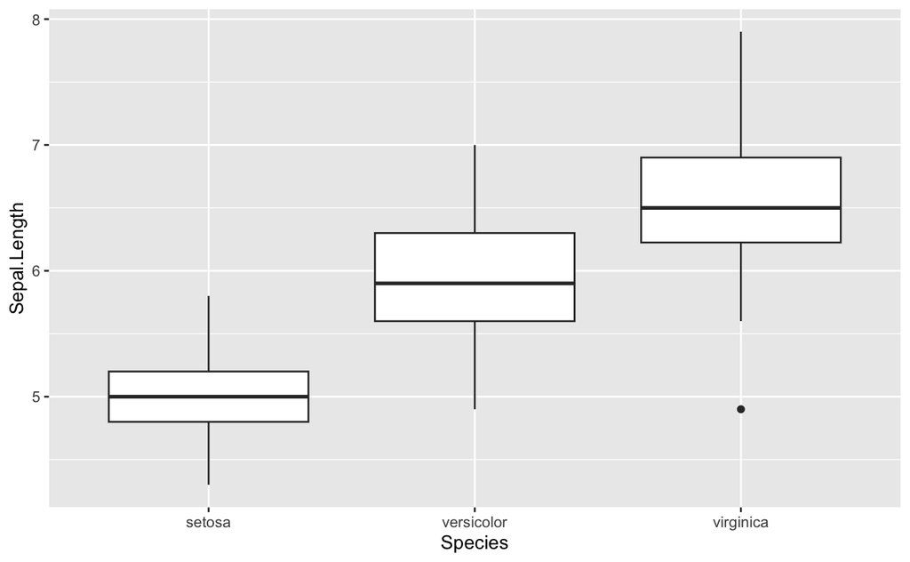

```r
ggplot(data = df_iris, aes(x = Species, y = Sepal.Length)) +
  geom_boxplot()
```

#### 1.5.1.6 [Histogram](https://ggplot2.tidyverse.org/reference/geom_histogram.html)

Visualize the distribution of a single continuous variable by dividing the x axis into bins and counting the number of observations in each bin. Histograms (geom_histogram()) display the counts with bars.

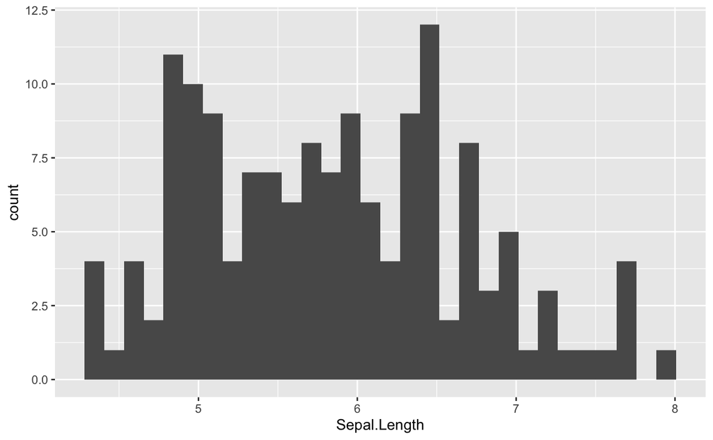

```r
ggplot(data = df_iris, aes(x = Sepal.Length)) +
  geom_histogram()
```

Change the number of bins by `bins =` `<number>`.

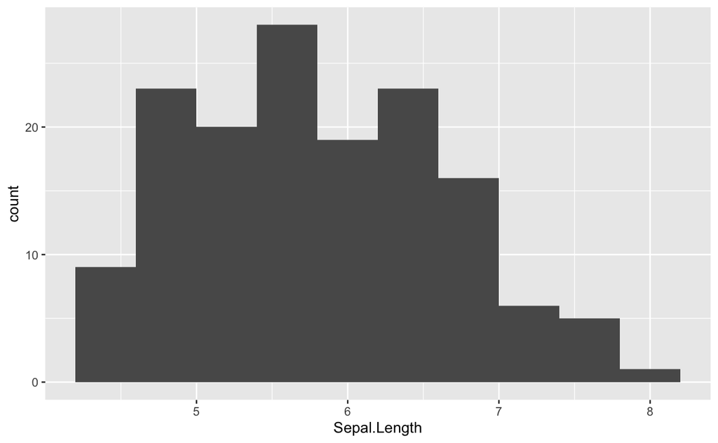

```r
ggplot(data = df_iris, aes(x = Sepal.Length)) +
  geom_histogram(bins = 10)
```

### 1.5.2 Data Modeling

Professor Kaizoji will cover the mathematical models and hypothesis testings.

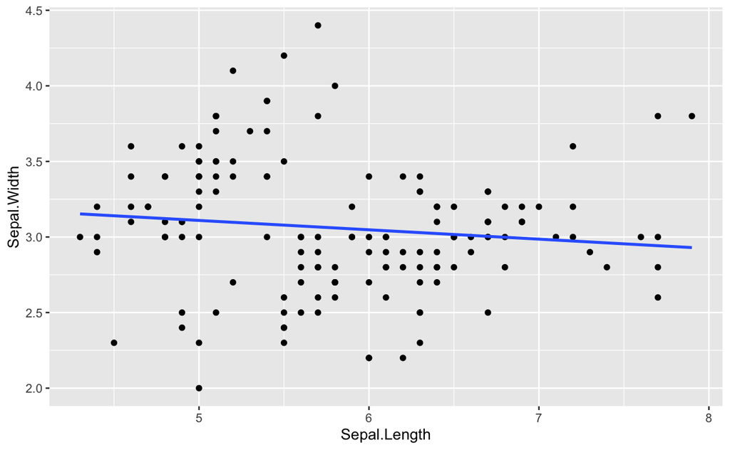

```r
ggplot(data = df_iris, aes(x = Sepal.Length, y = Sepal.Width)) +
  geom_point() +
  geom_smooth(method = "lm", se = FALSE)
```

## 1.6 Comments on Week 2

#### 1.6.0.1 Helpful Resources

- Cheat Sheet in RStudio: https://www.rstudio.com/resources/cheatsheets/
  - [RStudio IED](https://raw.githubusercontent.com/rstudio/cheatsheets/main/rstudio-ide.pdf)
  - [Base R Cheat Sheet](https://github.com/rstudio/cheatsheets/raw/main/base-r.pdf)
- ‘Quick R’ by DataCamp: https://www.statmethods.net/management
- [An Introduction to R](https://cran.rstudio.com)

#### 1.6.0.2 Practicum

- Posit Primers: The Basics: https://posit.cloud/learn/primers/1
  - Complete Visualization Basics and Programming Basics

#### 1.6.0.3 Assignments - See Moodle

1. Assignment Week 2-1: Introduction Plus Forum
- Due: Tuesday, 20 December 2022, 11:59 PM
2. Assignment Week 2-2: Quiz 1 on R Basics
- Due: Tuesday, 20 December 2022, 11:59 PM

## 1.7 Swirl: An interactive learning environment for R and statistics

- {`swirl`} website: https://swirlstats.com
- JHU Data Science in coursera uses `swirl` for exercises.

### 1.7.1 Swirl Courses

1. R Programming: The basics of programming in R
2. Regression Models: The basics of regression modeling in R
3. Statistical Inference: The basics of statistical inference in R
4. Exploratory Data Analysis: The basics of exploring data in R

You can install other `swirl` courses as well

- [Swirl Courses Organized by Title](http://swirlstats.com/scn/title.html)
- [Swirl Courses Organized by Author’s Name](http://swirlstats.com/scn/surname.html)
- [Github: swirl courses](https://github.com/swirldev/swirl_courses#swirl-courses)
  - `install_course("Course Name Here")`

### 1.7.2 Install and Start Swirl Courses

#### 1.7.2.1 Three Steps to Start Swirl

```
install.packages("swirl") # Only the first time.
library(swirl) # Everytime you start swirl
swirl() # Everytime you start or resume swirl
```

#### 1.7.2.2 R Programming: The basics of programming in R

```
 1: Basic Building Blocks      2: Workspace and Files     3: Sequences of Numbers
 4: Vectors                    5: Missing Values          6: Subsetting Vectors
 7: Matrices and Data Frames   8: Logic                   9: Functions
10: lapply and sapply         11: vapply and tapply      12: Looking at Data
13: Simulation                14: Dates and Times        15: Base Graphics
```

#### 1.7.2.3 Recommended Sections in Order

1, 3, 4, 5, 6, 7, 12, 15, 14, 8, 9, 10, 11, 13, 2

- Section 2 discusses the directories and file systems of a computer
- Sections 9, 10, 11 are for programming

#### 1.7.2.4 Controling a `swirl` Session

- … <– That’s your cue to press Enter to continue
- You can exit swirl and return to the R prompt (>) at any time by pressing the Esc key.
- If you are already at the prompt, type bye() to exit and save your progress. When you exit properly, you’ll see a short message letting you know you’ve done so.

When you are at the R prompt (>):

1. Typing skip() allows you to skip the current question.
2. Typing play() lets you experiment with R on your own; swirl will ignore what you do…
3. UNTIL you type nxt() which will regain swirl’s attention.
4. Typing bye() causes swirl to exit. Your progress will be saved.
5. Typing main() returns you to swirl’s main menu.
6. Typing info() displays these options again.

#### 1.7.2.5 Final Remark

You will encounter the message like ‘Would you like to receive credit for completing this course on Coursera.org?’ at the end of each course. This is for `coursera` courses. Select ‘NO’.

## 1.8 More on R Script: Examples

### 1.8.1 R Scripts in Moodle

- basics.R
- coronavirus.R
1. Copy a script in Moodle: *{file name}.R*
2. In RStudio (Workspace in RStudio.cloud, Project in RStudio) choose File > New File > R Script and paste it.
3. Choose File > Save with a name; e.g. *{file names}* (.R will be added automatically)

### 1.8.2 `basics.R`

```r
#################
#
# basics.R
#
################
# 'Quick R' by DataCamp may be a handy reference:
#     https://www.statmethods.net/management/index.html
# Cheat Sheet at RStudio: https://www.rstudio.com/resources/cheatsheets/
# Base R Cheat Sheet: https://github.com/rstudio/cheatsheets/raw/main/base-r.pdf
# To execute the line: Control + Enter (Window and Linux), Command + Enter (Mac)
## try your experiments on the console

## calculator

3 + 7

### +, -, *, /, ^ (or **), %%, %/%

3 + 10 / 2

3^2

2^3

2*2*2

### assignment: <-, (=, ->, assign())

x <- 5

x

#### object_name <- value, '<-' shortcut: Alt (option) + '-' (hyphen or minus)
#### Object names must start with a letter and can only contain letter, numbers, _ and .

this_is_a_long_name <- 5^3

this_is_a_long_name

char_name <- "What is your name?"

char_name

#### Use 'tab completion' and 'up arrow'

### ls(): list of all assignments

ls()
ls.str()

#### check Environment in the upper right pane

### (atomic) vectors

5:10

a <- seq(5,10)

a

b <- 5:10

identical(a,b)

seq(5,10,2) # same as seq(from = 5, to = 10, by = 2)

c1 <- seq(0,100, by = 10)

c2 <- seq(0,100, length.out = 10)

c1

c2

length(c1)

#### ? seq   ? length   ? identical

(die <- 1:6)

zero_one <- c(0,1) # same as 0:1

die + zero_one # c(1,2,3,4,5,6) + c(0,1). re-use

d1 <- rep(1:3,2) # repeat


d1

die == d1

d2 <- as.character(die == d1)

d2

d3 <- as.numeric(die == d1)

d3

### class() for class and typeof() for mode
### class of vectors: numeric, charcters, logical
### types of vectors: doubles, integers, characters, logicals (complex and raw)

typeof(d1); class(d1)

typeof(d2); class(d2)

typeof(d3); class(d3)

sqrt(2)

sqrt(2)^2

sqrt(2)^2 - 2

typeof(sqrt(2))

typeof(2)

typeof(2L)

5 == c(5)

length(5)

### Subsetting

(A_Z <- LETTERS)

A_F <- A_Z[1:6]

A_F

A_F[3]

A_F[c(3,5)]

large <- die > 3

large

even <- die %in% c(2,4,6)

even

A_F[large]

A_F[even]

A_F[die < 4]

### Compare df with df1 <- data.frame(number = die, alphabet = A_F)
df <- data.frame(number = die, alphabet = A_F, stringsAsFactors = FALSE)

df

df$number

df$alphabet

df[3,2]

df[4,1]

df[1]

class(df[1])

class(df[[1]])

identical(df[[1]], die)

identical(df[1],die)

####################
# The First Example
####################

plot(cars)

# Help

? cars

# cars is in the 'datasets' package

data()

# help(cars) does the same as ? cars
# You can use Help tab in the right bottom pane

help(plot)
? par

head(cars)

str(cars)

summary(cars)

x <- cars$speed
y <- cars$dist

min(x)
mean(x)
quantile(x)

plot(cars)

abline(lm(cars$dist ~ cars$speed))

summary(lm(cars$dist ~ cars$speed))

boxplot(cars)

hist(cars$speed)
hist(cars$dist)
hist(cars$dist, breaks = seq(0,120, 10))
```

### 1.8.3 coronavirus.R

```r
# https://coronavirus.jhu.edu/map.html
# JHU Covid-19 global time series data
# See R pakage coronavirus at: https://github.com/RamiKrispin/coronavirus
# Data taken from: https://github.com/RamiKrispin/coronavirus/tree/master/csv
# Last Updated
Sys.Date()

## Download and read csv (comma separated value) file
coronavirus <- read.csv("https://github.com/RamiKrispin/coronavirus/raw/master/csv/coronavirus.csv")
# write.csv(coronavirus, "data/coronavirus.csv")

## Summaries and structures of the data
head(coronavirus)
str(coronavirus)
coronavirus$date <- as.Date(coronavirus$date)
str(coronavirus)

range(coronavirus$date)
unique(coronavirus$country)
unique(coronavirus$type)

## Set Country
COUNTRY <- "Japan"
df0 <- coronavirus[coronavirus$country == COUNTRY,]
head(df0)
tail(df0)
(pop <- df0$population[1])
df <- df0[c(1,6,7,13)]
str(df)
head(df)
### alternatively,
head(df0[c("date", "type", "cases", "population")])
###

## Set types
df_confirmed <- df[df$type == "confirmed",]
df_death <- df[df$type == "death",]
df_recovery <- df[df$data_type == "recovery",]
head(df_confirmed)
head(df_death)
head(df_recovery)

## Histogram
plot(df_confirmed$date, df_confirmed$cases, type = "h")
plot(df_death$date, df_death$cases, type = "h")
# plot(df_recovered$date, df_recovered$cases, type = "h") # no data for recovery

## Scatter plot and correlation
plot(df_confirmed$cases, df_death$cases, type = "p")
cor(df_confirmed$cases, df_death$cases)


## In addition set a period
start_date <- as.Date("2021-07-01")
end_date <- Sys.Date()
df_date <- df[df$date >=start_date & df$date <= end_date,]
##

## Set types
df_date_confirmed <- df_date[df_date$type == "confirmed",]
df_date_death <- df_date[df_date$type == "death",]
df_date_recovery <- df_date[df_date$data_type == "recovery",]
head(df_date_confirmed)
head(df_date_death)
head(df_date_recovery)

## Histogram
plot(df_date_confirmed$date, df_date_confirmed$cases, type = "h")
plot(df_date_death$date, df_date_death$cases, type = "h")
# plot(df_date_recovered$date, df_date_recovered$cases, type = "h") # no data for recovery

plot(df_date_confirmed$cases, df_date_death$cases, type = "p")
cor(df_date_confirmed$cases, df_date_death$cases)

### Q0. Change the values of the location and the period and see the outcomes.
### Q1. What is the correlation between df_confirmed$cases and df_death$cases?
### Q2. Do we have a larger correlation value if we shift the dates to implement the time-lag?
### Q3. Do you have any other questions to explore?

#### Extra
plot(df_confirmed$date, df_confirmed$cases, type = "h",
     main = paste("Comfirmed Cases in",COUNTRY),
     xlab = "Date", ylab = "Number of Cases")
```

## 1.9 `gapminder` Package

### 1.9.1 Hans Rosling (1948 – 2017)

> Hans Rosling was a Swedish physician, academic, and public speaker. He was a professor of international health at Karolinska Institute[4] and was the co-founder and chairman of the Gapminder Foundation, which developed the Trendalyzer software system. ([wikipedia](https://en.wikipedia.org/wiki/Hans_Rosling))
- Books:
  - Factfulness: Ten Reasons We’re Wrong About The World - And Why Things Are Better Than You Think, 2018
  - How I Learned to Understand the World: A Memoir, 2020
- Gapminder: https://www.gapminder.org
  - [You are probably wrong about: Upgrade Your World View](https://upgrader.gapminder.org)
  - [Bubble Chart](https://www.gapminder.org/tools/#$state$time$value=2020;;&chart-type=bubbles): Income vs Life Expectancy over time, 1800 - 2020
    - How many variables?
- Videos: [The best stats you’ve ever seen, Hans Rosling](http://www.edtech.events/the-best-stats-youve-ever-seen-hans-rosling/)

### 1.9.2 Factfulness is … *From the book*

recognizing when a decision feels urgent and remembering that it rarely is.

To control the urgency instinct, take small steps.

- Take a breath. When your urgency instinct is triggered, your other instincts kick in and your analysis shuts down. Ask for more time and more information. It’s rarely now or never and it’s rarely either/or.
- Insist on the data. If something is urgent and important, it should be measured. Beware of data that is relevant but inaccurate, or accurate but irrelevant. Only relevant and accurate data is useful.
- Beware of fortune-tellers. Any prediction about the future is uncertain. Be wary of predictions that fail to acknowledge that. Insist on a full range of scenarios, never just the best or worst case. Ask how often such predictions have been right before.
- Be wary of drastic action. Ask what the side effects will be. Ask how the idea has been tested. Step-by-step practical improvements, and evaluation of their impact, are less dramatic but usually more effective.

```r
df <- gapminder
df
```

| country | continent | year | lifeExp | pop | gdpPercap |
| --- | --- | --- | --- | --- | --- |
| Afghanistan | Asia | 1952 | 28.80100 | 8425333 | 779.4453 |
| Afghanistan | Asia | 1957 | 30.33200 | 9240934 | 820.8530 |
| Afghanistan | Asia | 1962 | 31.99700 | 10267083 | 853.1007 |
| Afghanistan | Asia | 1967 | 34.02000 | 11537966 | 836.1971 |
| Afghanistan | Asia | 1972 | 36.08800 | 13079460 | 739.9811 |
| Afghanistan | Asia | 1977 | 38.43800 | 14880372 | 786.1134 |
| Afghanistan | Asia | 1982 | 39.85400 | 12881816 | 978.0114 |
| Afghanistan | Asia | 1987 | 40.82200 | 13867957 | 852.3959 |
| Afghanistan | Asia | 1992 | 41.67400 | 16317921 | 649.3414 |
| Afghanistan | Asia | 1997 | 41.76300 | 22227415 | 635.3414 |

[output cut: 990 more lines]

```r
glimpse(df)
```

```
Rows: 1,704
Columns: 6
$ country   <fct> "Afghanistan", "Afghanistan", "Afghanistan", "Afghanistan", "Afghanistan"…
$ continent <fct> Asia, Asia, Asia, Asia, Asia, Asia, Asia, Asia, Asia, Asia, Asia, Asia, E…
$ year      <int> 1952, 1957, 1962, 1967, 1972, 1977, 1982, 1987, 1992, 1997, 2002, 2007, 1…
$ lifeExp   <dbl> 28.801, 30.332, 31.997, 34.020, 36.088, 38.438, 39.854, 40.822, 41.674, 4…
$ pop       <int> 8425333, 9240934, 10267083, 11537966, 13079460, 14880372, 12881816, 13867…
$ gdpPercap <dbl> 779.4453, 820.8530, 853.1007, 836.1971, 739.9811, 786.1134, 978.0114, 852…
```

```r
summary(df)
```

```
        country        continent        year         lifeExp           pop
 Afghanistan:  12   Africa  :624   Min.   :1952   Min.   :23.60   Min.   :6.001e+04
 Albania    :  12   Americas:300   1st Qu.:1966   1st Qu.:48.20   1st Qu.:2.794e+06
 Algeria    :  12   Asia    :396   Median :1980   Median :60.71   Median :7.024e+06
 Angola     :  12   Europe  :360   Mean   :1980   Mean   :59.47   Mean   :2.960e+07
 Argentina  :  12   Oceania : 24   3rd Qu.:1993   3rd Qu.:70.85   3rd Qu.:1.959e+07
 Australia  :  12                  Max.   :2007   Max.   :82.60   Max.   :1.319e+09
 (Other)    :1632
   gdpPercap
 Min.   :   241.2
 1st Qu.:  1202.1
 Median :  3531.8
 Mean   :  7215.3
 3rd Qu.:  9325.5
 Max.   :113523.1
```

### 1.9.3 Questions

- List questions based on this data.
- What do you want to see?
- What kind of chart do you want to construct?